# Project2_Mai_Todd_Carlos

# Removing Variables

```r
# Remove the first three columns (e.g., ID and another non-predictive variable)
mydata <- mydata[, -c(1, 2, 3)]
```

# Checking for multicollinearity

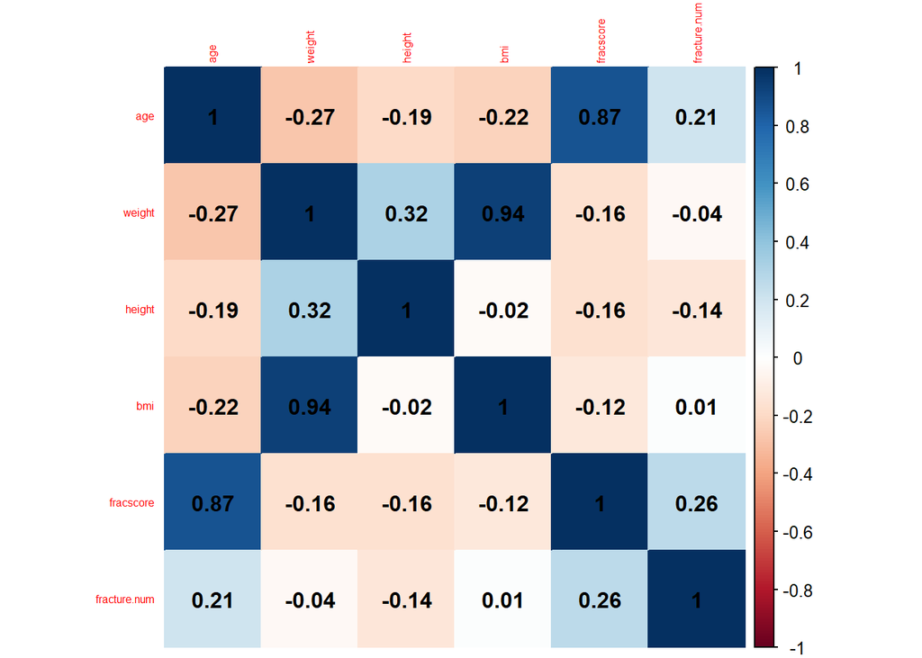

```r
library(corrplot)
#Corrplot

# Select only numeric columns from the data frame
numeric_data <- select_if(mydata, is.numeric)

# Compute the correlation matrix for numeric variables
cor_matrix <- cor(numeric_data)

# Customize corrplot (e.g., change color, method, etc.)
# For more customization options, check the documentation: ?corrplot
corrplot(cor_matrix, method = "color", tl.cex = 0.5,addCoef.col = "black")
```

This is another visualization to see the multicollinearity between the predictors, particularly between the age and the fracscore (cor = 0.87) and between the weight and the bmi (cor =0.94)

#PCA - Princinpal component analysis of the numerical variables

```r
# Load necessary libraries
library(ggplot2)
library(dplyr)

# Separate the diagnosis variable
Fracture <- mydata$fracture
# Remove the first two columns (e.g., ID and another non-predictive variable)

# Filter only numerical columns from your dataset (assuming they are columns 3 onwards)
numerical_data <- mydata %>% select_if(is.numeric)
#Remove the frac.num which is the response variable
numerical_data <- numerical_data[, -c(6)]
# Perform PCA
pc.result <- prcomp(numerical_data, scale. = TRUE)
```

# Scree plot of the numerical variables

```r
pc.result<-prcomp(mydata[,2:5,11],scale.=TRUE)

#Eigen Vectors
pc.result$rotation
```

```
##               PC1        PC2         PC3          PC4
## age     0.3274619  0.4399377 -0.83619052 -0.002982769
## weight -0.6704056  0.1148690 -0.20461452  0.703913597
## height -0.2330163 -0.7937338 -0.50799595 -0.240062702
## bmi    -0.6237214  0.4040378 -0.02929911 -0.668480853
```

```r
#Eigen Values
eigenvals<-pc.result$sdev^2
eigenvals
```

```
## [1] 2.11454918 1.07345979 0.80875185 0.00323919
```

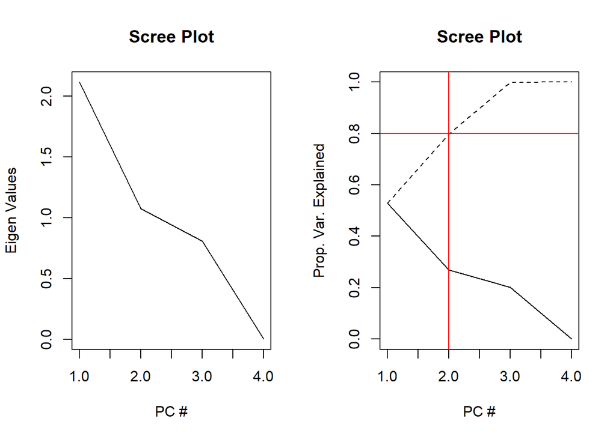

```r
#Scree plot
par(mfrow=c(1,2))
plot(eigenvals,type="l",main="Scree Plot",ylab="Eigen Values",xlab="PC #")
plot(eigenvals/sum(eigenvals),type="l",main="Scree Plot",ylab="Prop. Var. Explained",xlab="PC #",ylim=c(0,1))
cumulative.prop<-cumsum(eigenvals/sum(eigenvals))
lines(cumulative.prop,lty=2)
abline(v=2, col="red")
abline(h=0.8, col="red")
```

According to the scree plot, the first 2 principals components would be needed to retain approximately 80% of the total variation in the data set.

# Scatter Plot of PC1 and PC2

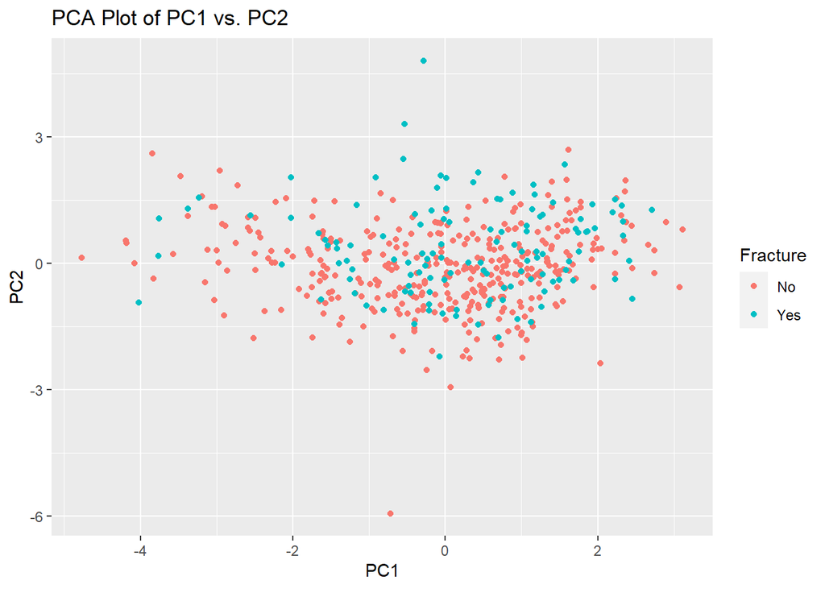

```r
# Create a data frame with PC1 and PC2
pca_df <- data.frame(PC1 = pc.result$x[, 1], PC2 = pc.result$x[, 2], Fracture = Fracture)

# Create a scatter plot of PC1 vs. PC2 color-coded by Fracture
ggplot(pca_df, aes(x = PC1, y = PC2, color = Fracture)) +
  geom_point() +
  labs(x = "PC1", y = "PC2", color = "Fracture") +
  ggtitle("PCA Plot of PC1 vs. PC2")
```

We know a good bit about the variables in our data set, we’ll move forward with preprocessing the data, splitting into train/validation sets and proceed with Objective 1.

# EDA For Objective 2

# Loading libraries

```r
library(caret)
library(ggplot2)
library(olsrr)
library(boot)
library(dplyr)
library(ggcorrplot)
library(naniar)
library(GGally)
library(plotly)
library(naniar)
library(ggExtra)
library(glmnet)
library(tree)
library(randomForest)
library(FNN)
library(olsrr)
library(stringr)
library(ResourceSelection)
library(car)
library(pROC)
library(gridExtra)
library(aplore3)
library(Metrics)
library(MASS)
library(ggraph)
library(igraph)
```

# Functions

## Functions to be rehused on the project

```r
df_raw_0 = glow_bonemed
df_clean_0 = df_raw_0

#Checking AGE
df_clean_0$fracture.num<-ifelse(df_clean_0$fracture=="Yes",1,0)
View(df_clean_0)

print_rf_tree = function(caret_model){
  tree_num <- which(caret_model$finalModel$forest$ndbigtree == min(caret_model$finalModel$forest$ndbigtree))
  tree_func(final_model = caret_model$finalModel, tree_num)

}

tree_func <- function(final_model,
                      tree_num) {

  # get tree by index
  tree <- randomForest::getTree(final_model,
                                k = tree_num,
                                labelVar = TRUE) %>%
    tibble::rownames_to_column() %>%
    # make leaf split points to NA, so the 0s won't get plotted
    mutate(`split point` = ifelse(is.na(prediction), `split point`, NA))

  # prepare data frame for graph
  graph_frame <- data.frame(from = rep(tree$rowname, 2),
                            to = c(tree$`left daughter`, tree$`right daughter`))

  # convert to graph and delete the last node that we don't want to plot
  graph <- graph_from_data_frame(graph_frame) %>%
    delete_vertices("0")

  # set node labels
  V(graph)$node_label <- gsub("_", " ", as.character(tree$`split var`))
  V(graph)$leaf_label <- as.character(tree$prediction)
  V(graph)$split <- as.character(round(tree$`split point`, digits = 2))

  # plot
  plot <- ggraph(graph, 'dendrogram') +
    theme_bw() +
    geom_edge_link() +
    geom_node_point() +
    geom_node_text(aes(label = node_label), na.rm = TRUE, repel = TRUE) +
    geom_node_label(aes(label = split), vjust = 2.5, na.rm = TRUE, fill = "white") +
    geom_node_label(aes(label = leaf_label, fill = leaf_label), na.rm = TRUE,
                    repel = TRUE, colour = "white", fontface = "bold", show.legend = FALSE) +
    theme(panel.grid.minor = element_blank(),
          panel.grid.major = element_blank(),
          panel.background = element_blank(),
          plot.background = element_rect(fill = "white"),
          panel.border = element_blank(),
          axis.line = element_blank(),
          axis.text.x = element_blank(),
          axis.text.y = element_blank(),
          axis.ticks = element_blank(),
          axis.title.x = element_blank(),
          axis.title.y = element_blank(),
          plot.title = element_text(size = 18))

  print(plot)
}


boundary <- function(model, data, class = NULL, predict_type = "class",
  resolution = 100, showgrid = TRUE, ...) {

  if(!is.null(class)) cl <- data[,class] else cl <- 1
  data <- data[,1:2]
  k <- length(unique(cl))

  plot(data, col = as.integer(cl)+1L, pch = as.integer(cl)+1L, ...)

  # make grid
  r <- sapply(data, range, na.rm = TRUE)
  xs <- seq(r[1,1], r[2,1], length.out = resolution)
  ys <- seq(r[1,2], r[2,2], length.out = resolution)
  g <- cbind(rep(xs, each=resolution), rep(ys, time = resolution))
  colnames(g) <- colnames(r)
  g <- as.data.frame(g)

  ### guess how to get class labels from predict
  ### (unfortunately not very consistent between models)
  p <- predict(model, g, type = predict_type)
  if(is.list(p)) p <- p$class
  p <- as.factor(p)

  if(showgrid) points(g, col = as.integer(p)+1L, pch = ".")

  z <- matrix(as.integer(p), nrow = resolution, byrow = TRUE)
  contour(xs, ys, z, add = TRUE, drawlabels = FALSE,
    lwd = 2, levels = (1:(k-1))+.5)

  invisible(z)
}

print_model_results = function(par.model,par.test.data,par.thhold,par.type){

  lmodel.lor.predprobs<-predict(par.model,par.test.data,type="response")
  lmodel.lor.prefact = rep("No", length(lmodel.lor.predprobs))
  lmodel.lor.prefact[lmodel.lor.predprobs > par.thhold] = "Yes"
  lmodel.lor.prefact = as.factor(lmodel.lor.prefact)

  lmodel.lor.roc<-roc(response=par.test.data$fracture,predictor=lmodel.lor.predprobs,levels=c("No","Yes"))

  #plot(lmodel.lor.roc, main = "ROC Curve Model")
  if(par.type==1){
    data_con = confusionMatrix(table(lmodel.lor.prefact,par.test.data$fracture))
    print(data_con)
  }
  if(par.type==2){
    data_con = confusionMatrix(table(lmodel.lor.prefact,par.test.data$fracture))
    print(data_con)
    plot(lmodel.lor.roc, main = "ROC Curve Model")
  }
  if(par.type==3){
    data_con = confusionMatrix(table(lmodel.lor.prefact,par.test.data$fracture))

    plot(lmodel.lor.roc, main = "ROC Curve Model")

    sum = summary(par.model)
    coef = coef(par.model)
    vif = vif(par.model)
    print(sum)
    print(coef)
    print(vif)
    print(data_con)

  }



}


print_log_loss = function(par.model,par.test.data,par.caret){

  if(par.caret == 0){
    lmodel.lor.predprobs=predict(par.model,par.test.data,type="response")
    #lmodel.lor.roc<-roc(response=par.test.data$fracture,predictor=lmodel.lor.predprobs,levels=c("No","Yes"))
  }else{
    lmodel.lor.predprobs = predict(par.model,par.test.data,type = "prob")[,"Yes"]
    #lmodel.lor.roc<-roc(response=par.test.data$fracture,predictor=lmodel.lor.predprobs[,"Yes"],levels=c("No","Yes"))
  }

  df.mod.testa = data.frame(val=par.test.data$fracture)
  df.mod.testa = df.mod.testa  %>% mutate(code = ifelse(val=="Yes",1,0))
  logLoss(df.mod.testa$code,lmodel.lor.predprobs)

}

print_auc = function(par.model,par.test.data,par.caret){

  if(par.caret == 0){
    lmodel.lor.predprobs=predict(par.model,par.test.data,type="response")
    #lmodel.lor.roc<-roc(response=par.test.data$fracture,predictor=lmodel.lor.predprobs,levels=c("No","Yes"))
  }else{
    lmodel.lor.predprobs = predict(par.model,par.test.data,type = "prob")[,"Yes"]
    #lmodel.lor.roc<-roc(response=par.test.data$fracture,predictor=lmodel.lor.predprobs[,"Yes"],levels=c("No","Yes"))
  }
  df.mod.testa = data.frame(val=par.test.data$fracture)
  df.mod.testa = df.mod.testa  %>% mutate(code = ifelse(val=="Yes",1,0))
  print(auc(actual = df.mod.testa$code,predicted = lmodel.lor.predprobs))

}



get_roc = function(par.model,par.test.data,par.caret){

  if(par.caret == 0){
    lmodel.lor.predprobs=predict(par.model,par.test.data,type="response")
    lmodel.lor.roc<-roc(response=par.test.data$fracture,predictor=lmodel.lor.predprobs,levels=c("No","Yes"))
  }else{
    lmodel.lor.predprobs = predict(par.model,par.test.data,type = "prob")
    lmodel.lor.roc<-roc(response=par.test.data$fracture,predictor=lmodel.lor.predprobs[,"Yes"],levels=c("No","Yes"))
  }
  # lmodel.lor.prefact = rep("No", length(lmodel.lor.predprobs))
  # lmodel.lor.prefact[lmodel.lor.predprobs > par.thhold] = "Yes"
  # lmodel.lor.prefact = as.factor(lmodel.lor.prefact)

  #lmodel.lor.roc<-roc(response=par.test.data$fracture,predictor=lmodel.lor.predprobs,levels=c("No","Yes"))
  return(lmodel.lor.roc)

}
```